# Presentation-Topic: Analysis and Prediction of Heart Failure

# **II. Description of the data set**

**1.Introduce about data set:**The data for the project is taken from the website ([Heart Failure Prediction Dataset| Kaggle](https://www.kaggle.com/datasets/fedesoriano/heart-failure-prediction?resource=download)).Includes 1 data set in the form (.csv) /heart.csv. * Information about the dataset that the team analyzed

```
 The dataset includes: 12 columns and 918 rows. Inside:
  * Categorical variables (qualitative): Sex, ChestPainType, FastingBS, RestingECG, ExerciseAngina, ST_Slope, HeartDisease
  * Variables (quantitative): Age, RestingBP, Cholesterol, MaxHR, Oldpeak
 - Age: Age of the patient
 - Sex: patient's sex [M: Male, F: Female]
 - ChestPainType: type of chest pain [TA: Typical angina, ATA: Atypical angina, NAP: No angina, ASY: No symptomatic]
 - RestingBP: resting blood pressure - resting blood pressure [mmHg]
 - Cholesterol: amount of cholesterol [mm/dl]
 - FastingBS: fasting blood sugar [1: ifFastingBS > 120 mg/dL, 0: if FastingBS <= 120 mg/dL]
 - RestingECG: ECG results at rest [Normal: Normal,ST: ST-T wave abnormalities (T wave inversion and/or ST elevation)or decrease > 0.05 mV), LVH: indicates possible left ventricular hypertrophy or determined according to Estes' criteria]
 - MaxHR: maximum heart rate achieved [Number value from 60 to 202]
 - ExerciseAngina: exercise-induced angina [Y: Yes, N: No]
 - Oldpeak: oldpeak = ST [Number value measured in depression]
 - ST_Slope: slope of the peak exercise ST segment [Up: uphill, Flat: flat, Down: sloping down]
 - HeartDisease: Heart disease [1: Yes, 0: No]
```

**2.How data is collected:** By installing the necessary libraries. we need to use read.csv() function and set correct path to .csv file and get result like below

```
##   Age Sex ChestPainType RestingBP Cholesterol FastingBS RestingECG MaxHR
## 1  40   M           ATA       140         289         0     Normal   172
## 2  49   F           NAP       160         180         0     Normal   156
## 3  37   M           ATA       130         283         0         ST    98
## 4  48   F           ASY       138         214         0     Normal   108
## 5  54   M           NAP       150         195         0     Normal   122
## 6  39   M           NAP       120         339         0     Normal   170
##   ExerciseAngina Oldpeak ST_Slope HeartDisease
## 1              N     0.0       Up            0
## 2              N     1.0     Flat            1
## 3              N     0.0       Up            0
## 4              Y     1.5     Flat            1
## 5              N     0.0       Up            0
## 6              N     0.0       Up            0
```

** Check if the data is empty or not?

```
##            Age            Sex  ChestPainType      RestingBP    Cholesterol
##              0              0              0              0              0
##      FastingBS     RestingECG          MaxHR ExerciseAngina        Oldpeak
##              0              0              0              0              0
##       ST_Slope   HeartDisease
##              0              0
```

**Comment:** output shows no empty data

** Check for duplicate data.

```
## [1] 0
```

**Comment:**output shows no duplicate data

** Display by data summary variable:

```
##       Age            Sex            ChestPainType        RestingBP
##  Min.   :28.00   Length:918         Length:918         Min.   :  0.0
##  1st Qu.:47.00   Class :character   Class :character   1st Qu.:120.0
##  Median :54.00   Mode  :character   Mode  :character   Median :130.0
##  Mean   :53.51                                         Mean   :132.4
##  3rd Qu.:60.00                                         3rd Qu.:140.0
##  Max.   :77.00                                         Max.   :200.0
##   Cholesterol      FastingBS       RestingECG            MaxHR
##  Min.   :  0.0   Min.   :0.0000   Length:918         Min.   : 60.0
##  1st Qu.:173.2   1st Qu.:0.0000   Class :character   1st Qu.:120.0
##  Median :223.0   Median :0.0000   Mode  :character   Median :138.0
##  Mean   :198.8   Mean   :0.2331                      Mean   :136.8
##  3rd Qu.:267.0   3rd Qu.:0.0000                      3rd Qu.:156.0
##  Max.   :603.0   Max.   :1.0000                      Max.   :202.0
##  ExerciseAngina        Oldpeak          ST_Slope          HeartDisease
##  Length:918         Min.   :-2.6000   Length:918         Min.   :0.0000
##  Class :character   1st Qu.: 0.0000   Class :character   1st Qu.:0.0000
##  Mode  :character   Median : 0.6000   Mode  :character   Median :1.0000
##                     Mean   : 0.8874                      Mean   :0.5534
##                     3rd Qu.: 1.5000                      3rd Qu.:1.0000
##                     Max.   : 6.2000                      Max.   :1.0000
```

# **III. Data analysis**

**Questions chosen by the group**

- Question 1: How does high cholesterol affect the risk of heart disease?
- Question 2: Do men have a higher risk of heart disease than women?
- Question 3: Of the factors in the data, which are the main factors that lead to a higher risk of heart failure?
- Question 4: Use Logistic Regression model to predict whether a person is likely to have heart disease or not?

# **Solve the question 1: How does high cholesterol affect the risk of heart disease?**

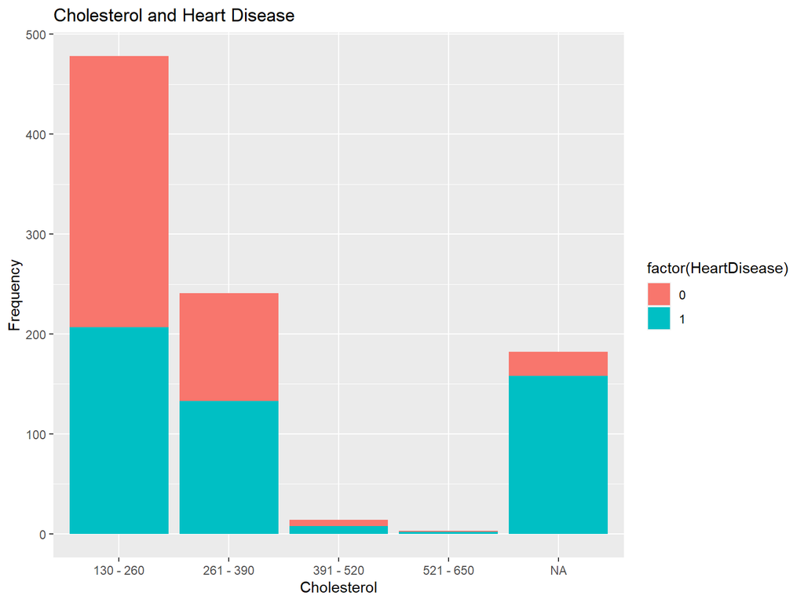

```
## People with cholesterol from 130 - 260 have 43.31% possibility of heart disease
```

```
## People with cholesterol from 261 - 390 have 55.19% possibility of heart disease
```

```
## People with cholesterol from 391 - 520 have 57.14% possibility of heart disease
```

```
## People with cholesterol from 521 - 650 have 66.67% possibility of heart disease
```

- Through the ratio above, we can see that the higher the cholesterol, the higher the risk of heart disease. From there we have measures to balance the amount of cholesterol that we absorb. And can prevent heart failure.

# **Solve the question 2: Do men have a higher risk of heart disease than women?**

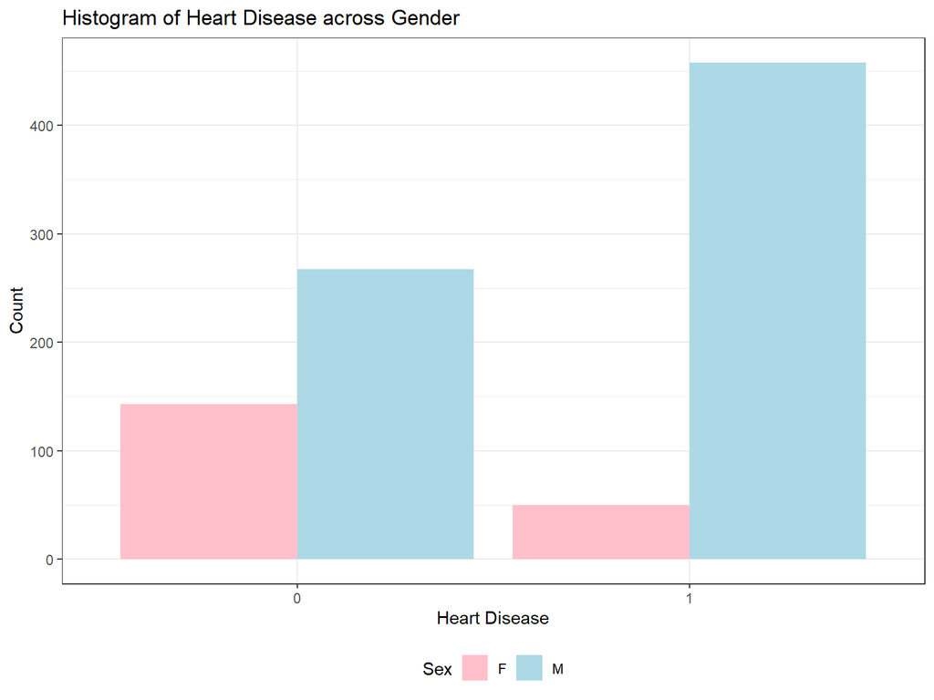

- The number of men with heart disease is higher than that of men without heart disease, the number of women with heart disease is lower than the number of women without heart disease.

## Using the test of statistical significance:

- H0: Gender does not affect the likelihood of heart disease
- H1: Men are more likely to have heart disease than women

```
##
##  Welch Two Sample t-test
##
## data:  MaleHD$HeartDisease and FemaleHD$HeartDisease
## t = 10.253, df = 326.32, p-value < 2.2e-16
## alternative hypothesis: true difference in means is not equal to 0
## 99 percent confidence interval:
##  0.2784831 0.4668304
## sample estimates:
## mean of x mean of y
## 0.6317241 0.2590674
```

- **Comment:**
  - Since the p value < 0.05 is statistically significant, we reject H0 and accept H1.
  - Men have a 28%-47% higher risk of heart disease than women.
  - The percentage of men with heart disease in the dataset accounted for 63.17% and women with heart disease accounted for 25.9%

# **Solve the question 3: Of the factors in the data, which are the main factors that lead to a higher risk of heart failure?**

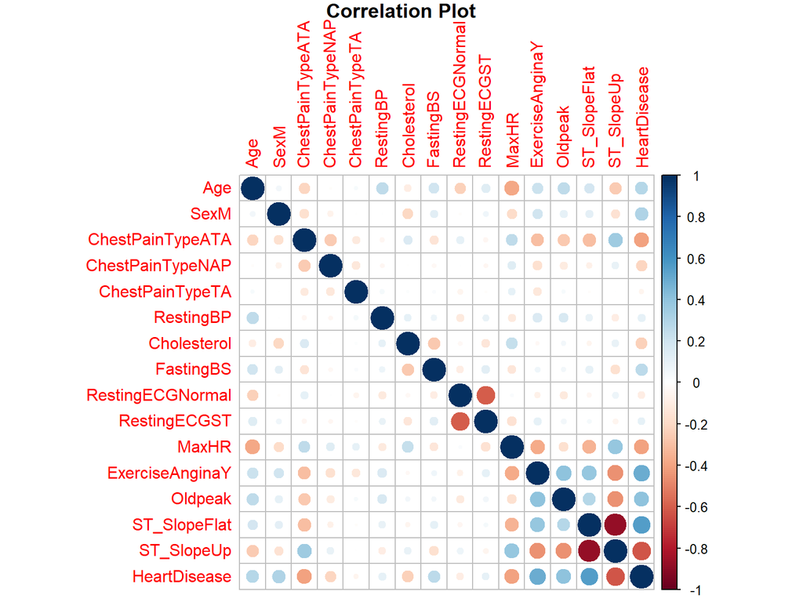

```
- Comment:

 - The correlation chart shows the correlation between variables visually, the darker the color, the stronger the correlation.

 - Looking at the graph we can see that the variables Age, SexM, ChestPainTypeATA, ChestPainTypeNAP, Cholesterol, FastingBS, MaxHR, ExerciseAnginaY, Oldpeak, ST_SlopeFlat and ST_SlopeUp are highly correlated with the outcome variable.

 - The ST_Slope variable has the strongest correlation with the outcome variable.
```

```
##                     Variables Importance Rank
## FastingBS           FastingBS      11.13  #11
## RestingBP           RestingBP      31.93   #8
## MaxHR                   MaxHR      49.09   #3
## ExerciseAngina ExerciseAngina      34.86   #6
## Cholesterol       Cholesterol      47.95   #4
## Sex                       Sex      16.24   #9
## ChestPainType   ChestPainType      57.33   #2
## RestingECG         RestingECG      11.82  #10
## ST_Slope             ST_Slope     103.23   #1
## Age                       Age      34.45   #7
## Oldpeak               Oldpeak      47.84   #5
```

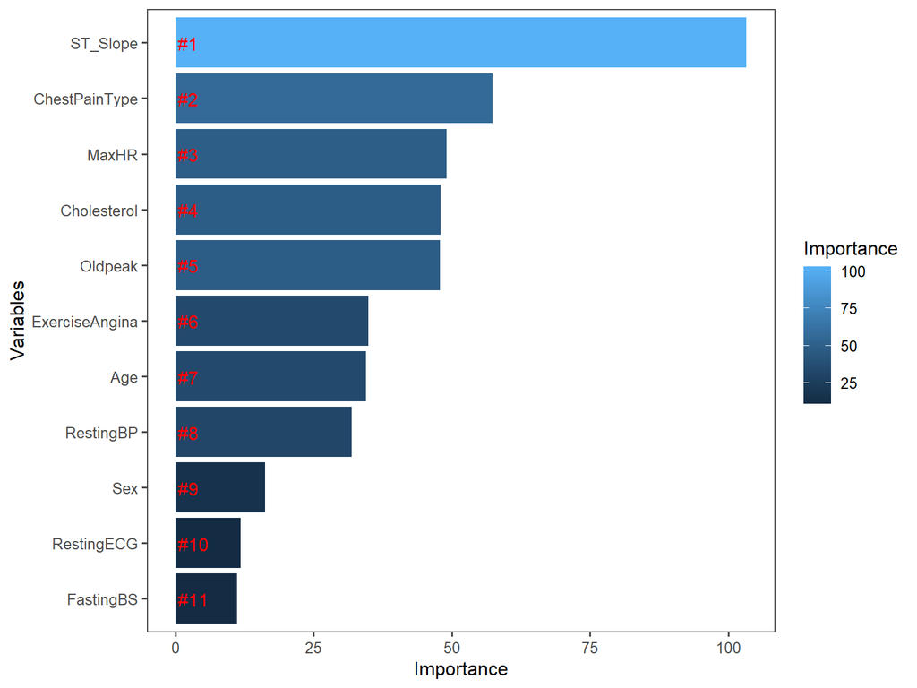

- From this model, we can also see that the variable ST_Slope is the variable that has the most influence on heart disease.